# Inclusion of Women in the R Community

### Heather Turner

#### *and the Women in R Taskforce:*

#### Jenny Bryan, Di Cook, Julie Josse, Oliver Keyes, Michael Lawrence, Kevin O’Brien, Alicia Oshlack, Carolin Strobl

#### June 23, 2016

# The R Community

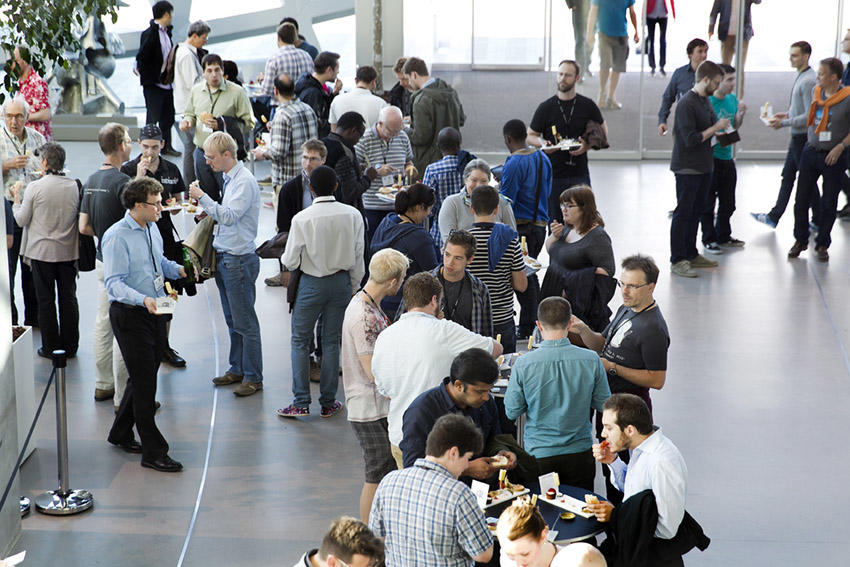

© Torben Tvedebrink 2015

# The R Community

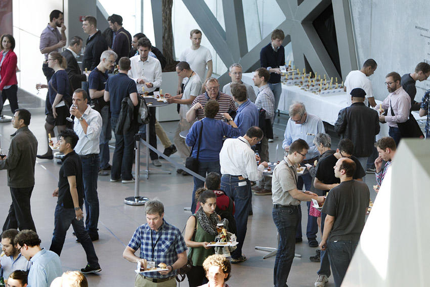

© Torben Tvedebrink 2015

# The R Community

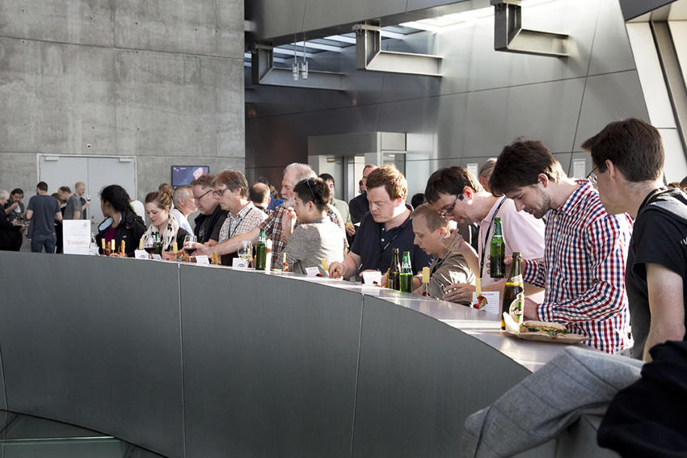

© Torben Tvedebrink 2015

- How well are women *actually* represented in the R community?
- Are women *proportionately* represented in the R community?
- What can be done to increase women’s participation?

# Where we are now

# Conferences

- At useR! 2015, ~19% participants were women
- The percentage of presentations was the same, with slight bias towards posters/lightning talks

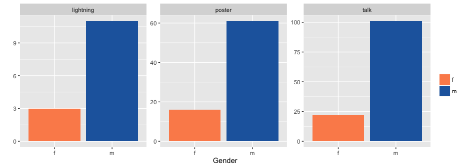

# Packages

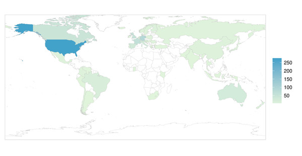

[figure not shown]

¹Mair, P., Hofmann, E., Gruber, K., Hatzinger, R., Zeleis, A. and Hornik, K. (2015) Motivation, values, and work design as drivers of participation in the R open source project for statistical computing, PNAS

# Packages

- All CRAN maintainers (Mar 2016) processed with **genderizer**
  - uses databases to predict gender from first name
- Supplemented by manual assignment
- 14.8% package authors “female”, 11.4% with P(gender) ≥ 0.8 only

[figure not shown]

# Other R Project Contributions

- 18% Google Summer of Code 2015 mentors were women (9 individuals)
- In remaining cases, percentages represent one or two women

[figure not shown]

# Where should we be?

# US Students

- Data from US National Center for Education Statistics (2013-14)
- Computer science ranges from 18% (Bachelor’s) to 29% (Master’s) female
- Others range from 29% to 58% female

[figure not shown]

# US Occupations

- Data from American Community Survey 2014
- 22% female programmers
- Other scientific/analytic occupations at least 41% female

[figure not shown]

# Goals for R Community

- Developers (CRAN maintainers, GSoC students, ISC funding holders) should at least be comparable to computer science figures
  - > 20% women
- Broader user community (R conference attendees/speakers, RUG members) should at least be comparable to mathematical/natural sciences
  - 30-40% women

# How can we get there?

# R Foundation Women in R Taskforce

> to improve the participation and experience of women in the R community

Jenny Bryan  
CA

Alicia Oshlack  
AU

Oliver Keyes  
US

Di Cook  
AU

Carolin Strobl  
CH

Kevin O’Brien  
IE

Julie Josse  
FR

Heather Turner  
UK

Michael Lawrence  
US

# Twitter

- **@RWomenTaskforce**
  - promote female-led R workshops/webinars
  - share articles/initiatives on encouraging diversity
- Share info to tweet/re-tweet:
  - GMT: **@dragonflystats**, kobriendublin@gmail.com
  - Pacific: **@JennyBryan**, jenny@stat.ubc.ca
  - AEST: **@AliciaOshlack**, alicia.oshlack@mcri.edu.au

[Tweets by RWomenTaskforce](https://twitter.com/RWomenTaskforce)

# Website/GitHub

- http://forwards.github.io/
  - Summary of where we are
  - Events calendar
- Coming soon!
  - Data and code for gender summaries
  - Links to resources on diversity in tech
  - More as initiative develops!

[interactive chart not shown]

# Data Monitoring

|  | **Details** | **Done** | **To Do** |
| --- | --- | --- | --- |
| useR! | attendees, invited speakers, presenters (talk/lightning/poster), chairs, committee members (local/program) | 2015 | 2004-2014 |
| packages | CRAN maintainers/authors, others? | maintainers | authors |
| GSoC | students, mentors | 2015 | 2008-2014 |
| ISC projects | proposers | funded | rejected? |
| R Journal | editors, authors | editors | authors |

# Surveys

- Get input from the community on obstacles and ideas for improvements
- Target survey at particular populations, e.g.
  - useR! attendees
  - local user group attendees
  - package maintainers
  - R-help users
  - StackOverflow users
- Create bank of questions and customise survey for target group
- First survey will be of useR! 2016 participants (June 27-30)

# Conferences

- useR! has already been working to improve diversity
  - gradual increase in number of female keynotes
  - code of conduct introduced in 2015
  - diversity scholarships & mothers’ room in 2016

[figure not shown]

# Conferences

- The taskforce made recommendations for useR! 2016

  | **Recomendation** | **Action** |
  | --- | --- |
  | 50:50 program committee | 7:6 female:male |
  | 50:50 session chairs | 7:18 |
  | ≥ 20% women on panels | NA |
  | put gender stats on website | not done |

- Future useR!s
  - maintain current gender balance for invited speakers
  - aim for similar gender balance for tutors: 28% had female tutor in 2015
- useR! 2017 proposal includes offering childcare

# Recruiting Ambassadors

- WiR emailed prominent women in R community

[figure not shown]

- Some already active, other prompted to act as ambassadors

> I am actually working with the conference committee on funding a female grad student or post doc to go to the conference … I will definitely get the word out  
> – Mine Çetinkaya-Rundel, email

> I’m making myself available to help on giving feedback, helping on ideas, reviews of abstracts, etc. I would love to see more R-ladies presenting at useR!  
> – Gabriela de Queiroz, message on meetup

# Pycon

[figure not shown]

[figure not shown]

[figure not shown]

It starts with outreach!

# PyLadies

- 61 groups worldwide
  - including Brazil, Turkey, Nigeria, India, Morocco, Korea, Taiwan
- Mentorship to help women become more active in Python community
  - hackathons
  - workshops
  - social events
  - fundraising

[figure not shown]

[figure not shown]

credit: DC PyLadies

# R-ladies

- 2 active groups
  - the original: R-Ladies San Fransisco
  - new for 2016:  
    R-ladies London
- Example events
  - drop-in session for beginners
  - tutorials
  - “Tour de R”
  - SF uncubed: recruiting tech event

[figure not shown]

[figure not shown]

credit: Chiin-Rui Tan

# R User Groups

- 237 local RUGs
- Heading for 20 RUG meetings per week, somewhere in the world
- Short talks, “show and tell”

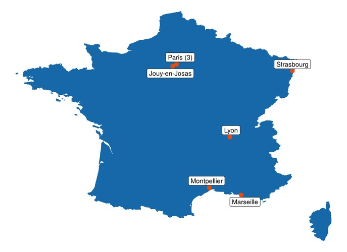

# RUGs as a Springboard

- Opportunity for women
  - practice public speaking (conference format)
  - get feedback on projects
  - relatively low-cost (short talk, local venue)
- Organisers can help
  - small numbers of speakers: not so hard to balance program
  - try lightning talks, e.g. recent DublinR 2 male, 3 female
  - low risk inviting new people

# Female-friendly R Workshops

- Not restricted to R-ladies groups!
  - female only/ males +1s
  - majority female mentors
- Potential Women in R workshops?
  - beginner workshops in partnership with RUGS
  - summer school for aspiring package developers (Europe 2018)

# Google Summer of Code

1. Mentors/students propose 3 month projects
2. Google awards a fixed number of student slots
3. Admins & mentors select projects
   - student earns $5500
   - mentors benefit from contribution to their project

R’s contribution from ideas to implementation managed via GitHub github.com/rstats-gsoc

# Google Summer of Code

summerofcode.withgoogle.com

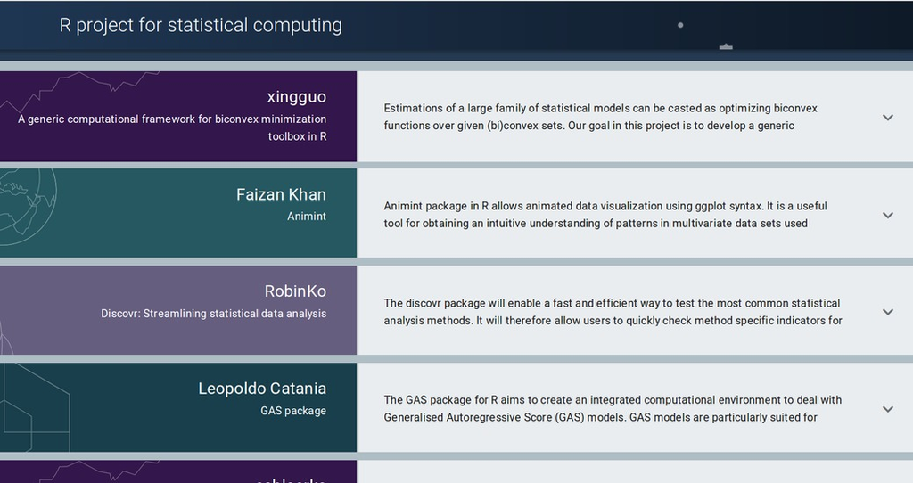

# On Ramps for Contributing

- Several R packages on GitHub have a CONTRIBUTING.md
  - often not designed for novices
- Target issues at novices
  - use tags
  - step-by-step instructions

[figure not shown]

credit: Charlotte Spencer

# Mentoring

[figure not shown]

- Open issue on GitHub and Tweet request for review
- Study group/RUG code swaps
- Consultancy
- Scaling rOpenSci???

# rOpenSci

- R packages to access scientific data; visualize; document & share data
- Community support
  - open review process
  - support with maintenance
  - package promotion
- Unconference (43% non-male)

[figure not shown]

credit: Gabriela de Queiroz

# R Consortium ISC

- The R Consortium is a framework for the support of R by industry
- Its Infrastructure Steering Committee offers funding for projects
  - software development
  - developing teaching materials
  - documenting best practices
  - standardising APIs
  - research

# Funded ISC Projects

- **R-Hub**: pre-test CRAN packages on multiple platforms, automate package building
- A unified framework for distributed computing in R
- Improving database interface (**DBI**)
- R Implementation, Optimization and Tooling Workshops (**RIOT**)
- R Localization (**RL10N**): enable packages to include translations
- **SatRdays**: regional conferences
- Simple Features access for R: utilities for geospatial data
- Software Carpentry R instructor training

# Take-homes

# For Women Starting Out

- Find support
  - R-ladies/RUG/Study group
- Start small
  - Contribute to existing package
  - Make a package of personal utility functions
- Put on your flame-proof suit and ask stupid questions

  > If nm is double, very likely INTEGER(nm)[0] is negative and your C code does nothing at all. Hence it could be fast but useless.  
  > – Reply to me on R-help, 2005
- Publish code to get feedback and credit

# For Established Women

- Stay visible
  - Speak at conferences
  - Don’t hang out in clique at meetings
  - Be active online: Twitter, Blog, StackOverflow, GitHub, …
- Mentor other women
  - R-ladies/Female-friendly workshop
  - Encourage contributions on own projects, GSoC
- Consider applying for ISC funding

# For Everyone

- Be aware of (other) women’s contributions
  - Attend talks - even if you can only drop in
  - Invite women to low-key events (RUG, departmental seminar)
- Encourage women’s participation
  - Nominate for speakers, committee members, awards, …
  - Invite onto your project
- Promote welcoming culture
  - Use gender neutral language
  - Give constructive feedback

# Summary

- Women are under-represented in both user and developer communities
  - Users ~ 20% women; goal 30-40% women
  - Developers ~ 10% women; goal 20% women
- Women in R Taskforce has been established to address this
  - Current focus: data gathering, communications
  - Future work: outreach

@RWomenTaskforce

http://forwards.github.io/